# Migration

Vincent BISQUAY GRACIA

2021

# I. Set up

Used pakages :

```r
setwd(
  "D:/Users/181248/Documents/R")
library(raster)
library(rgdal)
library(devtools)
library(sf)
library(nngeo)
library(ggplot2)
library(ggrepel)
library(cowplot)
#install_github("jeffreyevans/spatialEco")
library(spatialEco)
library(magrittr)
library(svMisc)
```

```r
BAU_input =
  "D:/Users/181248/Documents/Klamath_(CA_only)_2021 - Harvest BAU/..1/biomass/"
Adapty_input =
  "D:/Users/181248/Documents/Klamath_(CA_only)_2021 - Harvest Adaptability/..1/biomass/"
```

```r
OnlyCA = raster(
  "D:/Users/181248/Documents/Klamath_(CA_only)_2021 - Harvest BAU/..1/Ownership_OnlyCA.tif")
CRSRef = crs(OnlyCA)
NrowRef = OnlyCA@nrows
NcolRef = OnlyCA@ncols
ResRef = res(OnlyCA)[1]
XminRef = OnlyCA@extent@xmin
XmaxRef = OnlyCA@extent@xmax
YminRef = OnlyCA@extent@ymin
YmaxRef = OnlyCA@extent@ymax
```

# II. Calculus of the variables

## II.A Raster used

### II.A.1. Altitude raster

To compute the mean altitude of the species, an altitude raster is used ( /! ask source to Charles). Its extent is obtained using the raster of reference.

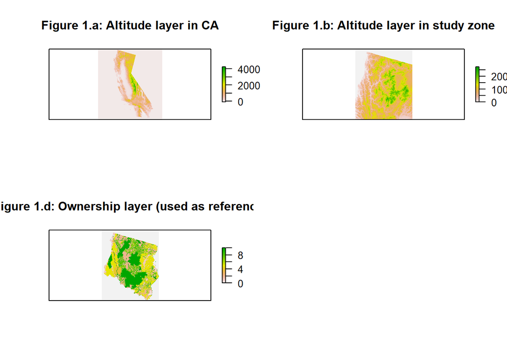

```r
AltTot =
  raster("D:/Users/181248/Documents/CA_elev_merged_clipped_epsg5070.tif")

Alt = crop(AltTot, OnlyCA)

par(mfrow=c(2,2))
plot(AltTot, main = "Figure 1.a: Altitude layer in CA",
     xaxt="n", yaxt="n")
plot(Alt, main = "Figure 1.b: Altitude layer in study zone",
     xaxt="n", yaxt="n")
plot(OnlyCA, main = "Figure 1.d: Ownership layer (used as reference)",
     xaxt="n", yaxt="n")
```

```r
SoilMoistInit =
  raster("D:/Users/181248/Documents/Annual-water-budget-1.img")

SoilMoist = raster(vals=getValues(SoilMoistInit),
                    nrow=NrowRef,ncol=NcolRef,resolution=ResRef,
                    xmn=XminRef, xmx=XmaxRef,ymn =YminRef,ymx=YmaxRef,crs=CRSRef)
```

### II.A.2. Rasters of biomass by species

A list *ListNamesTot* containing the 31 species names plus the “Total Biomass” mention is created.

Another list, *ListData* contains the names of all the biomass output maps of the simulation. There is 1 map per year (year 0 to year 100) and per species (plus the “Total Biomass”), so 3232 maps in total.

```r
SpeciesData = read.csv(
  "D:/Users/181248/Documents/Species_description.csv")

BAU_ListData = list.files(
  path = BAU_input, pattern = "\\.tif$")
Adapty_ListData = list.files(
  path = Adapty_input, pattern = "\\.tif$")

ListNames = as.vector(SpeciesData$Name)
ListNamesTot = c(ListNames[1:30],"TotalBiomass",ListNames[31])
```

This *ListData* will be used to import the rasters.

```r
head(BAU_ListData)
```

```
## [1] "AbieAmab-0.tif"   "AbieAmab-1.tif"   "AbieAmab-10.tif"  "AbieAmab-100.tif"
## [5] "AbieAmab-11.tif"  "AbieAmab-12.tif"
```

```r
head(Adapty_ListData)
```

```
## [1] "AbieAmab-0.tif"   "AbieAmab-1.tif"   "AbieAmab-10.tif"  "AbieAmab-100.tif"
## [5] "AbieAmab-11.tif"  "AbieAmab-12.tif"
```

We observe here that the last simulation (year 100) is at 4th position for each species.

For all species number $i\in[1,32]$, we want to compare the year 0 biomass map to the year 100 biomass map, *i.e.* compare the map number $id_{0} = 100*(i-1)+i$ to the map number $id_{100} = id_{0}+3$.

## II.B. Variables used

### II.B.1. Construction of the migration variable

For each species, at each scenario, the mean shift in coordinates and the mean shift in altitude are calculated.

With :

- $C_{ij}(t=0)_{x}$ and $C_{ij}(t=0)_{y}$ the two coordinates of the centroid of the biomass of the species $i \in [1,32]$ in the scenario $j \in [1,2]$ and at the initial conditions (at year 0). This centroid is calculated weighed by the biomass of each poin.
- $C_{ij}(t=100)_{x}$ and $C_{ij}(t=100)_{y}$ the coordinates of the same centroid but calculated at the end of the simulation (at year 100).

The mean altitude shift $Zshift_{ij}$ of the species $i$ in the scenario $j$ is calculated as :

$$Zshift_{ij} = \overline{Z_{ij}(t=100)}-\overline{Z_{ij}(t=0)}$$

With :

- $\overline{Z_{ij}(t=0)}$ the mean altitude of all the points containing the species $i \in [1,32]$ in the scenario $j \in [1,2]$ and at the initial conditions (at year 0). This mean altitude is calculated weighed by the biomass of each poin.

$\overline{Z_{ij}(t=100)}$ the same, but at the end of the simulation (at year 100).

These three operations are done in each one of the scenarios, and all the results are compiled in the dataframe *Results*.

```r
Results = c("Name", "Scenario", "Migration_x", "Migration_y","Migration_Altitude", "Migration_SoilMoist" ,"Distribution", "Group")
```

### II.B.2. Loop

For the species $i$, the previous calculus are done for each one of the scenarios.

```r
for(i in (1:32)){
  name = ListNamesTot[i]
  id0 = 100*(i-1)+i
  id100 = id0+3

  ### Scenario 1 (BAU only):

  ## Centroid of the intitial distribution of biomass of the species i(t=0)
  BAU_year0NoDef = paste(BAU_input,BAU_ListData[id0],sep="") %>% raster()
  BAU_year0 = raster(vals=getValues(BAU_year0NoDef),
                    nrow=NrowRef,ncol=NcolRef,resolution=ResRef,
                    xmn=XminRef, xmx=XmaxRef,ymn =YminRef,ymx=YmaxRef,crs=CRSRef)
  BAU_points0 = rasterToPoints(BAU_year0, fun = function(x){x>=1}, spatial = T)
  BAU_Centroid0 = wt.centroid(BAU_points0,"layer", sp=T)

  # Mean altitude of all the points, weighted by the biomass
  BAU_alt0_df = raster::extract(Alt, BAU_points0, method="simple", df=T) %>%
    cbind(BAU_points0$layer)
  BAU_alt0 = weighted.mean(x=BAU_alt0_df[,2], w=BAU_alt0_df[,3])

  # Mean soil moisture of all the points, weighted by the biomass
  BAU_sm0_df = raster::extract(SoilMoist, BAU_points0, method="simple", df=T) %>%
    cbind(BAU_points0$layer)
  BAU_sm0 = weighted.mean(x=BAU_sm0_df[,2], w=BAU_sm0_df[,3])

  ## Centroid of the final distribution of biomass of the species i(t=100)
  BAU_year100NoDef = paste(BAU_input,BAU_ListData[id100],sep="") %>% raster()
  BAU_year100 = raster(vals=getValues(BAU_year100NoDef),
                      nrow=NrowRef,ncol=NcolRef,resolution=ResRef,
                      xmn=XminRef, xmx=XmaxRef,ymn =YminRef,ymx=YmaxRef,crs=CRSRef)
  BAU_points100 = rasterToPoints(BAU_year100, fun = function(x){x>=1}, spatial = T)
  BAU_Centroid100 = wt.centroid(BAU_points100,"layer", sp=T)

  # Mean altitude of all the points, weighted by the biomass
  BAU_alt100_df = raster::extract(Alt, BAU_points100, method="simple", df=T) %>%
    cbind(BAU_points100$layer)
  BAU_alt100 = weighted.mean(x=BAU_alt100_df[,2], w=BAU_alt100_df[,3])

   # Mean soil moisture of all the points, weighted by the biomass
  BAU_sm100_df = raster::extract(SoilMoist, BAU_points100, method="simple", df=T) %>%
    cbind(BAU_points100$layer)
  BAU_sm100 = weighted.mean(x=BAU_sm100_df[,2], w=BAU_sm100_df[,3])

  ## Shift in coordinates of the centroids
  BAU_Migration_x = BAU_Centroid0@coords[1]-BAU_Centroid100@coords[1]
  BAU_Migration_y = BAU_Centroid0@coords[2]-BAU_Centroid100@coords[2]

  # Shift in Altitude
  BAU_Migration_alt = BAU_alt100-BAU_alt0

   # Shift in soil moisture
  BAU_Migration_sm = BAU_sm100-BAU_sm0

  ### Scenario 2 (adaptability):

  Adapty_year0NoDef = paste(Adapty_input,Adapty_ListData[id0],sep="") %>% raster()
  Adapty_year0 = raster(vals=getValues(Adapty_year0NoDef),
                      nrow=NrowRef,ncol=NcolRef,resolution=ResRef,
                      xmn=XminRef, xmx=XmaxRef,ymn =YminRef,ymx=YmaxRef,crs=CRSRef)
  Adapty_points0 = rasterToPoints(Adapty_year0, fun = function(x){x>=1}, spatial = T)
  Adapty_Centroid0 = wt.centroid(Adapty_points0,"layer", sp=T)

  Adapty_alt0_df = raster::extract(Alt, Adapty_points0, method="simple", df=T) %>%
    cbind(Adapty_points0$layer)
  Adapty_alt0 = weighted.mean(x=Adapty_alt0_df[,2], w=Adapty_alt0_df[,3])

  Adapty_sm0_df = raster::extract(SoilMoist, Adapty_points0, method="simple", df=T) %>%
    cbind(Adapty_points0$layer)
  Adapty_sm0 = weighted.mean(x=Adapty_sm0_df[,2], w=Adapty_sm0_df[,3])

  Adapty_year100NoDef = paste(Adapty_input,Adapty_ListData[id100],sep="") %>% raster()
  Adapty_year100 = raster(vals=getValues(Adapty_year100NoDef),nrow=NrowRef,
                        ncol=NcolRef,resolution=ResRef,
                        xmn=XminRef, xmx=XmaxRef,ymn =YminRef,ymx=YmaxRef,crs=CRSRef)
  Adapty_points100 = rasterToPoints(Adapty_year100, fun = function(x){x>=1}, spatial = T)
  Adapty_Centroid100 = wt.centroid(Adapty_points100,"layer", sp=T)

  Adapty_alt100_df = raster::extract(Alt, Adapty_points100, method="simple", df=T) %>%
    cbind(Adapty_points100$layer)
  Adapty_alt100 = weighted.mean(x=Adapty_alt100_df[,2], w=Adapty_alt100_df[,3])

  Adapty_sm100_df = raster::extract(SoilMoist, Adapty_points100, method="simple", df=T) %>%
    cbind(Adapty_points100$layer)
  Adapty_sm100 = weighted.mean(x=Adapty_sm100_df[,2], w=Adapty_sm100_df[,3])

  Adapty_Migration_x = Adapty_Centroid0@coords[1]-Adapty_Centroid100@coords[1]
  Adapty_Migration_y = Adapty_Centroid0@coords[2]-Adapty_Centroid100@coords[2]

  Adapty_Migration_alt = Adapty_alt100-Adapty_alt0

  Adapty_Migration_sm = Adapty_sm100-Adapty_sm0

  ### Position of the distribution area and functional group
  ### of the species i

  if (name == "TotalBiomass"){ # The total biomass raster
    #does not correspond to a species, so this values are empty.
    Distrib = ""
    Group = ""
  }else {
    Distrib = SpeciesData$Situation.of.NE.CA.in.the.distribution.area[which(SpeciesData$Name == name)]
    Group = SpeciesData$Functional.type.name[which(SpeciesData$Name == name)]
  }

  ### Compiling the information in a data frame

  Results = rbind(Results, c(name, "BAU", BAU_Migration_x, BAU_Migration_y,
                             BAU_Migration_alt, BAU_Migration_sm, Distrib, Group))
  Results = rbind(Results, c(name, "Adapty", Adapty_Migration_x,Adapty_Migration_y,
                             Adapty_Migration_alt, Adapty_Migration_sm, Distrib, Group))

#  progress(i, progress.bar = T)

}
```

## II.C. Dataframe of measurements

The first row of the dataframe *Results* will be used as column name, and the good type is gived to the data.

```r
Results = as.data.frame(Results)
colnames(Results)=Results[1,] %>% unlist %>% as.character
Results=Results[-1,]

Results$Migration_x = Results$Migration_x %>%
  as.character %>% as.numeric
Results$Migration_y = Results$Migration_y %>%
  as.character %>% as.numeric
Results$Migration_Altitude = Results$Migration_Altitude %>%
  as.character %>% as.numeric
Results$Migration_SoilMoist = Results$Migration_SoilMoist %>%
  as.character %>% as.numeric

head(Results)
```

```
##         Name Scenario Migration_x Migration_y Migration_Altitude
## X   AbieAmab      BAU    7339.133  -2145.9063          103.21847
## X.1 AbieAmab   Adapty   11725.996   3411.9671           29.63660
## X.2 AbieGran      BAU   50923.306   -460.0703         -688.00518
## X.3 AbieGran   Adapty   55426.840  -1728.7893         -760.20248
## X.4 AbieMagn      BAU   -3943.523  22149.9463           80.87258
## X.5 AbieMagn   Adapty    2416.696  28393.7874           69.22068
##     Migration_SoilMoist Distribution       Group
## X            31.5940777          XXS Abies mesic
## X.1          56.8573313          XXS Abies mesic
## X.2          44.7051286            S Abies mesic
## X.3          49.6570917            S Abies mesic
## X.4          -5.8901498            M Abies mesic
## X.5          -0.3055264            M Abies mesic
```

The total biomass, the species and the trees species are isolated in others dataframes. Doing a dataframe without the shrubs will be interesting when looking at the distribution area, as it is not evaluated for these organisms.

```r
TotBiom = subset(Results, Name == "TotalBiomass")

ResultSp = subset(Results, Name != "TotalBiomass")

ResultTree = subset(ResultSp, Distribution != "")
```

# III. Analyses of the West-Est and North-South shifts

## III.A. Visualisation of the data

### III.A.1. General behavior of the species

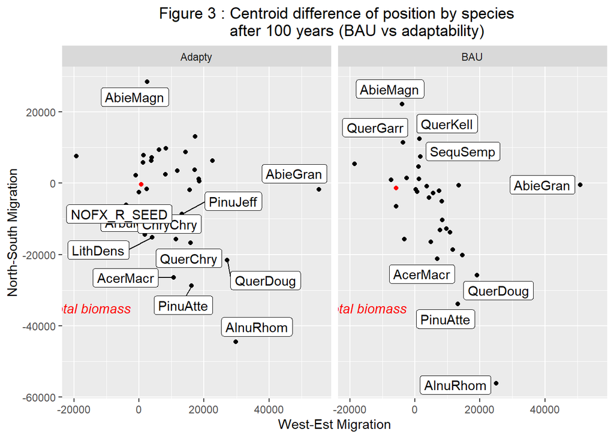

```r
ggplot(ResultSp, aes(x=Migration_x, y=Migration_y, label=Name)) +
  geom_point() +
  geom_point(data=TotBiom, colour="red")+
  scale_x_continuous(name= "West-Est Migration") +
  scale_y_continuous(name = "North-South Migration") +
  ggtitle(" Figure 3 : Centroid difference of position by species
          after 100 years (BAU vs adaptability)") +
  theme(plot.title = element_text(hjust = 0.5)) +
  geom_label_repel() +
  annotate("text", x = -20000, y = -35000, label = "Red : total biomass",
           colour = "red", fontface="italic") +
  facet_wrap(~Scenario)
```

### III.A.2. Influence of the area of distribution

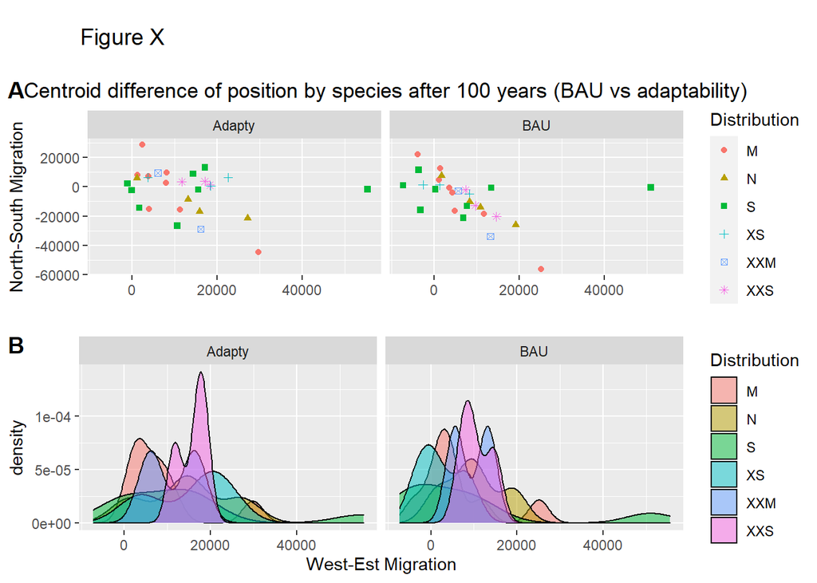

```r
title = ggdraw() +
  draw_label(
    "Figure X",
    fontface = 'plain', x = 0, hjust = 0, size = 14) +
    theme(plot.margin = margin(0, 0, 0, 50))

Points = ggplot(ResultTree, aes(x=Migration_x, y=Migration_y, col=Distribution, shape = Distribution)) +
  geom_point() +
  scale_x_continuous(name= "") +
  scale_y_continuous(name = "North-South Migration") +
  ggtitle("Centroid difference of position by species after 100 years (BAU vs adaptability)") +
  theme(plot.title = element_text(hjust = 0.5)) +
  facet_wrap(~Scenario)

Dens = ggplot(ResultTree, aes(Migration_x, fill=Distribution)) + geom_density(alpha=.5) +
  xlab("West-Est Migration") + ylab("density") +
  facet_wrap(~Scenario, ncol=2)

plot_row = plot_grid(Points, Dens, ncol=1, labels="AUTO")

plot_grid(title, plot_row, ncol=1, rel_heights = c(0.1, 0.7))
```

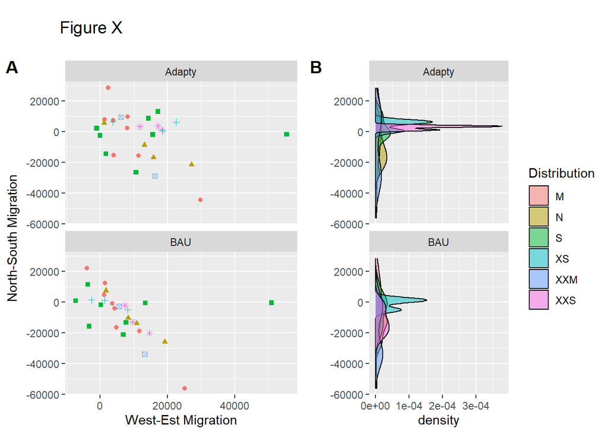

```r
title = ggdraw() +
  draw_label(
    "Figure X",
    fontface = 'plain', x = 0, hjust = 0, size = 14) +
    theme(plot.margin = margin(0, 0, 0, 50))

Points = ggplot(ResultTree, aes(x=Migration_x, y=Migration_y, col=Distribution, shape = Distribution)) +
  geom_point() +
  scale_x_continuous(name= "West-Est Migration") +
  scale_y_continuous(name = "North-South Migration") +
  theme(plot.title = element_text(hjust = 0.5)) +
  guides(color = FALSE, shape = FALSE) +
  facet_wrap(~Scenario, nrow=2)

Dens = ggplot(ResultTree, aes(Migration_y, fill=Distribution)) + geom_density(alpha=.5) +
  xlab("") + ylab("density") +
  coord_flip() +
  facet_wrap(~Scenario, nrow=2)

plot_row = plot_grid(Points, Dens, ncol=2, labels="AUTO")

plot_grid(title, plot_row, ncol=1, rel_heights = c(0.1, 0.7))
```

No trends.

### III.A.3. Looking at the type of ligneous species

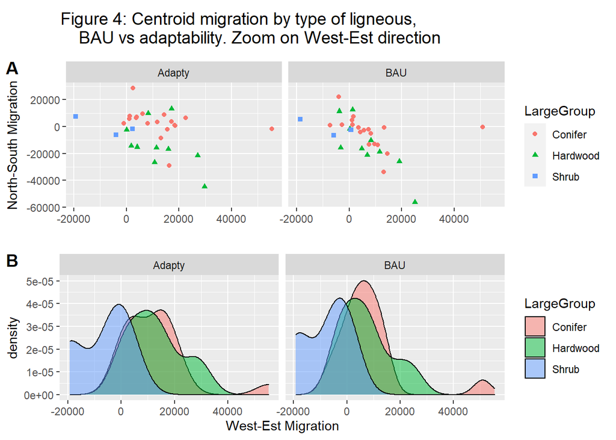

```r
title = ggdraw() +
  draw_label(
    "Figure 4: Centroid migration by type of ligneous,
    BAU vs adaptability. Zoom on West-Est direction",
    fontface = 'plain', x = 0, hjust = 0, size = 14) +
    theme(plot.margin = margin(0, 0, 0, 50))

ResultSp$LargeGroup = "Shrub"

ResultSp$LargeGroup[which(ResultSp$Group == "Abies dry" |
                            ResultSp$Group == "Abies mesic" |
                            ResultSp$Group == "Conifer dry" |
                            ResultSp$Group == "Conifer mesic")] = "Conifer"

ResultSp$LargeGroup[which(ResultSp$Group == "Hardwood mesic" |
                            ResultSp$Group == "Hardwood dry" |
                            ResultSp$Group == "Hardwood dry2")]= "Hardwood"

Points = ggplot(ResultSp, aes(x=Migration_x, y=Migration_y, col=LargeGroup, shape = LargeGroup)) +
  geom_point() +
  scale_x_continuous(name= "") +
  scale_y_continuous(name = "North-South Migration") +
  theme(plot.title = element_text(hjust = 0.5)) +
  facet_wrap(~Scenario)

Dens = ggplot(ResultSp, aes(Migration_x, fill=LargeGroup)) + geom_density(alpha=.5) +
  xlab("West-Est Migration") + ylab("density") +
  facet_wrap(~Scenario, ncol=2)

plot_row = plot_grid(Points, Dens, ncol=1, labels="AUTO")

plot_grid(title, plot_row, ncol=1, rel_heights = c(0.1, 0.7))
```

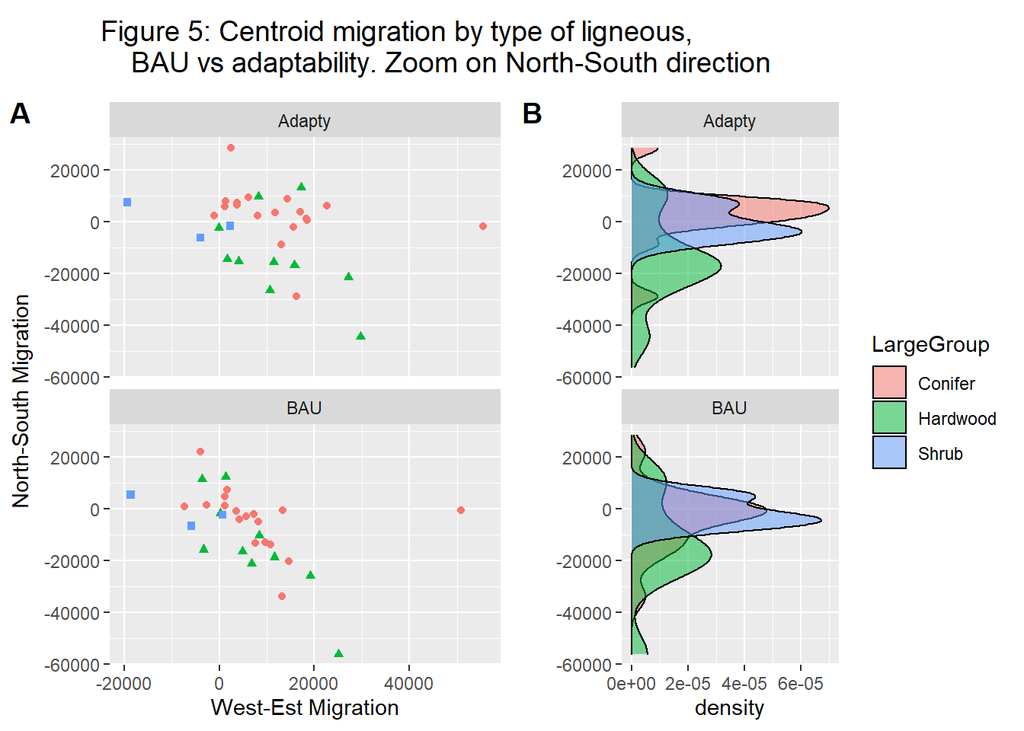

```r
title = ggdraw() +
  draw_label(
    "Figure 5: Centroid migration by type of ligneous,
    BAU vs adaptability. Zoom on North-South direction",
    fontface = 'plain', x = 0, hjust = 0, size = 14) +
    theme(plot.margin = margin(0, 0, 0, 50))

Points = ggplot(ResultSp, aes(x=Migration_x, y=Migration_y, col=LargeGroup, shape = LargeGroup)) +
  geom_point() +
  scale_x_continuous(name= "West-Est Migration") +
  scale_y_continuous(name = "North-South Migration") +
  theme(plot.title = element_text(hjust = 0.5)) +
  guides(color = FALSE, shape = FALSE) +
  facet_wrap(~Scenario, nrow=2)

Dens = ggplot(ResultSp, aes(Migration_y, fill=LargeGroup)) + geom_density(alpha=.5) +
  xlab("") + ylab("density") +
  coord_flip() +
  facet_wrap(~Scenario, nrow=2)

plot_row = plot_grid(Points, Dens, ncol=2, labels="AUTO")

plot_grid(title, plot_row, ncol=1, rel_heights = c(0.1, 0.7))
```

### III.A.4. Looking at the moisture preferencies

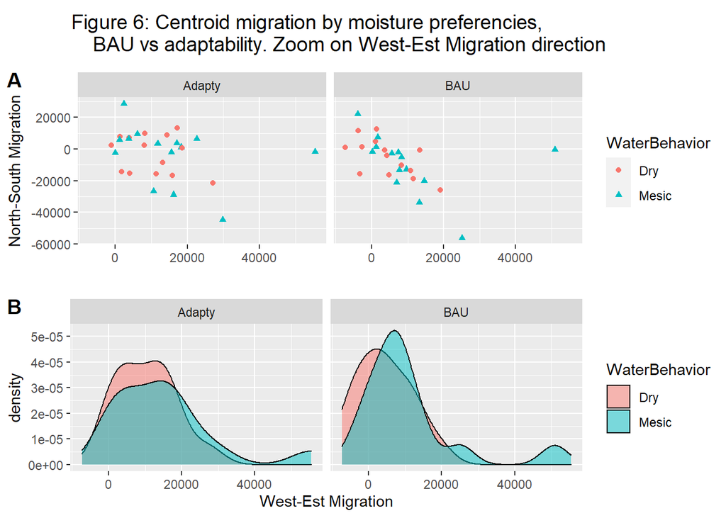

```r
ResultTree$WaterBehavior = "Shrub"

ResultTree$WaterBehavior[which(ResultTree$Group == "Abies dry" |
                            ResultTree$Group == "Hardwood dry" |
                            ResultTree$Group == "Conifer dry" |
                            ResultTree$Group == "Hardwood dry2")] = "Dry"

ResultTree$WaterBehavior[which(ResultTree$Group == "Hardwood mesic" |
                            ResultTree$Group == "Abies mesic" |
                            ResultTree$Group == "Conifer mesic")]= "Mesic"

title = ggdraw() +
  draw_label(
    "Figure 6: Centroid migration by moisture preferencies,
    BAU vs adaptability. Zoom on West-Est Migration direction",
    fontface = 'plain', x = 0, hjust = 0, size = 14) +
    theme(plot.margin = margin(0, 0, 0, 50))

Points = ggplot(ResultTree, aes(x=Migration_x, y=Migration_y, col=WaterBehavior, shape = WaterBehavior)) +
  geom_point() +
  scale_x_continuous(name= "") +
  scale_y_continuous(name = "North-South Migration") +
  theme(plot.title = element_text(hjust = 0.5)) +
  facet_wrap(~Scenario)

Dens = ggplot(ResultTree, aes(Migration_x, fill=WaterBehavior)) + geom_density(alpha=.5) +
  xlab("West-Est Migration") + ylab("density") +
  facet_wrap(~Scenario, ncol=2)

plot_row = plot_grid(Points, Dens, ncol=1, labels="AUTO")

plot_grid(title, plot_row, ncol=1, rel_heights = c(0.1, 0.7))
```

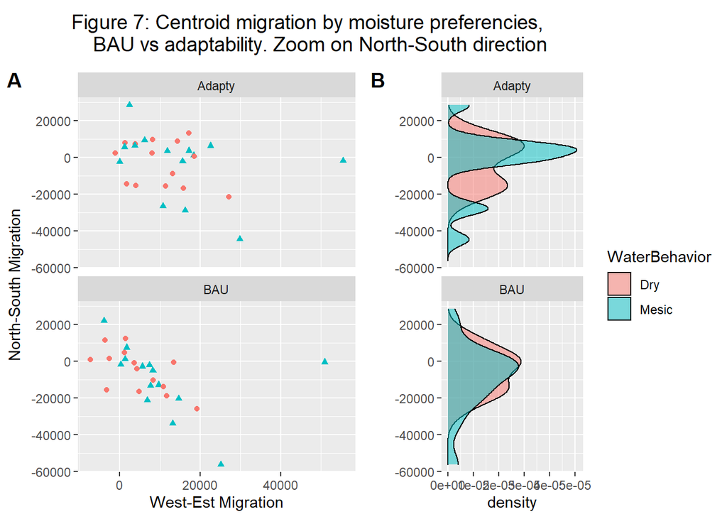

```r
title = ggdraw() +
  draw_label(
    "Figure 7: Centroid migration by moisture preferencies,
    BAU vs adaptability. Zoom on North-South direction",
    fontface = 'plain', x = 0, hjust = 0, size = 14) +
    theme(plot.margin = margin(0, 0, 0, 50))

Points = ggplot(ResultTree, aes(x=Migration_x, y=Migration_y, col=WaterBehavior, shape = WaterBehavior)) +
  geom_point() +
  scale_x_continuous(name= "West-Est Migration") +
  scale_y_continuous(name = "North-South Migration") +
  theme(plot.title = element_text(hjust = 0.5)) +
  guides(color = FALSE, shape = FALSE) +
  facet_wrap(~Scenario, nrow = 2)

Dens = ggplot(ResultTree, aes(Migration_y, fill=WaterBehavior)) + geom_density(alpha=.5) +
  xlab("") + ylab("density") +
  coord_flip() +
  facet_wrap(~Scenario, nrow=2)

plot_row = plot_grid(Points, Dens, ncol=2, labels="AUTO")

plot_grid(title, plot_row, ncol=1, rel_heights = c(0.1, 0.7))
```

## III.B. Statistical analyses

### III.B.1. West_Est axes

```r
shapiro.test(ResultSp$Migration_x[which(ResultSp$Scenario=="BAU")])
```

```
##
##  Shapiro-Wilk normality test
##
## data:  ResultSp$Migration_x[which(ResultSp$Scenario == "BAU")]
## W = 0.86919, p-value = 0.001336
```

```r
shapiro.test(ResultSp$Migration_x[which(ResultSp$Scenario=="Adapty")])
```

```
##
##  Shapiro-Wilk normality test
##
## data:  ResultSp$Migration_x[which(ResultSp$Scenario == "Adapty")]
## W = 0.90837, p-value = 0.01174
```

The p-value is significant, so the normality is invalidated. As the initial conditions of the two scenarios are the same, the means we want to compare come from paired samples. The test of mean comparison to use is then the Wilcoxon Rank Sum and Signed Rank Test.

```r
Xmean_BAU = mean(ResultSp$Migration_x[which(ResultSp$Scenario=="BAU")])
Xsd_BAU = sd(ResultSp$Migration_x[which(ResultSp$Scenario=="BAU")])

Xmean_Adapty = mean(ResultSp$Migration_x[which(ResultSp$Scenario=="Adapty")])
Xsd_Adapty = sd(ResultSp$Migration_x[which(ResultSp$Scenario=="Adapty")])

data.frame("X coordinate Mean" = c(Xmean_BAU,Xmean_Adapty), "Standard error" = c(Xsd_BAU, Xsd_Adapty),
           row.names = c("Business as usual","adaptability"))
```

```
##                   X.coordinate.Mean Standard.error
## Business as usual          6008.352       11904.06
## adaptability              10756.447       12937.95
```

```r
wilcox.test(ResultSp$Migration_x~ResultSp$Scenario, paired = T)
```

```
##
##  Wilcoxon signed rank exact test
##
## data:  ResultSp$Migration_x by ResultSp$Scenario
## V = 468, p-value = 1.381e-06
## alternative hypothesis: true location shift is not equal to 0
```

```r
DifTot = c("Name", "X_Dif", "Y_Dif", "Alt_Dif", "SoilMoist_Dif")

for(sp in ListNamesTot) {

BAU_X = Results$Migration_x[which(Results$Scenario=="BAU" & Results$Name==sp)]
Adapty_X = Results$Migration_x[which(Results$Scenario=="Adapty" & Results$Name==sp)]
Xdif = (BAU_X-Adapty_X)/BAU_X

BAU_Y = Results$Migration_y[which(Results$Scenario=="BAU" & Results$Name==sp)]
Adapty_Y = Results$Migration_y[which(Results$Scenario=="Adapty" & Results$Name==sp)]
Ydif = (BAU_Y-Adapty_Y)/BAU_Y

BAU_Alt = Results$Migration_Altitude[which(Results$Scenario=="BAU" & Results$Name==sp)]
Adapty_Alt = Results$Migration_Altitude[which(Results$Scenario=="Adapty" & Results$Name==sp)]
Altdif = (BAU_Alt-Adapty_Alt)/BAU_Alt

BAU_sm = Results$Migration_SoilMoist[which(Results$Scenario=="BAU" & Results$Name==sp)]
Adapty_sm = Results$Migration_SoilMoist[which(Results$Scenario=="Adapty" & Results$Name==sp)]
smdif = (BAU_sm-Adapty_sm)/BAU_sm

DifTot = rbind(DifTot, c(sp, Xdif, Ydif, Altdif, smdif))

}

DifTot = as.data.frame(DifTot)
colnames(DifTot)=DifTot[1,] %>% unlist %>% as.character
DifTot=DifTot[-1,]

Dif = subset(DifTot, Name != "TotalBiomass")

Dif$X_Dif = Dif$X_Dif %>% as.numeric()

Dif$Y_Dif = Dif$Y_Dif %>% as.numeric()

Dif$Alt_Dif = Dif$Alt_Dif %>% as.numeric()

Dif$SoilMoist_Dif = Dif$SoilMoist_Dif %>% as.numeric()
```

The total biomass, the species and the trees species are isolated in others dataframes. Doing a dataframe without the shrubs will be interesting when looking at the distribution area, as it is not evaluated for these organisms.

```r
TotBiom = subset(Results, Name == "TotalBiomass")

ResultSp = subset(Results, Name != "TotalBiomass")

ResultTree = subset(ResultSp, Distribution != "")
```

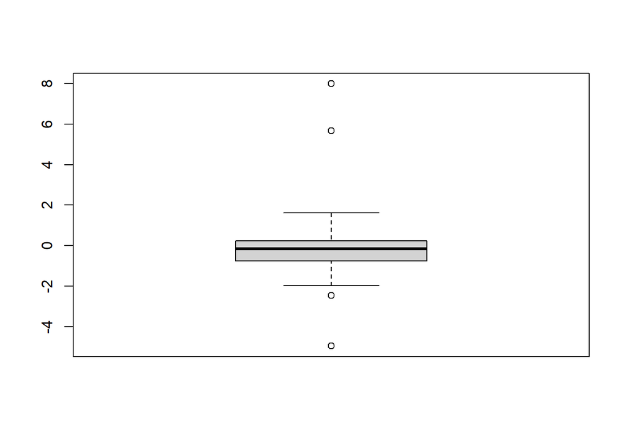

```r
boxplot(Dif$X_Dif)
```

```r
shapiro.test(Dif$X_Dif)
```

```
##
##  Shapiro-Wilk normality test
##
## data:  Dif$X_Dif
## W = 0.77021, p-value = 1.519e-05
```

### III.B.2. North-South direction

```r
shapiro.test(Results$Migration_y[which(Results$Scenario=="BAU")])
```

```
##
##  Shapiro-Wilk normality test
##
## data:  Results$Migration_y[which(Results$Scenario == "BAU")]
## W = 0.92563, p-value = 0.02963
```

```r
shapiro.test(Results$Migration_y[which(Results$Scenario=="Adapty")])
```

```
##
##  Shapiro-Wilk normality test
##
## data:  Results$Migration_y[which(Results$Scenario == "Adapty")]
## W = 0.92451, p-value = 0.02761
```

The p-value is significant, so the normality is invalidated. As the initial conditions of the two scenarios are the same, the means we want to compare come from paired samples. The test of mean comparison to use is then the Wilcoxon Rank Sum and Signed Rank Test.

```r
Ymean_BAU = mean(ResultSp$Migration_y[which(ResultSp$Scenario=="BAU")])
Ysd_BAU = sd(Results$Migration_y[which(ResultSp$Scenario=="BAU")])

Ymean_Adapty = mean(ResultSp$Migration_y[which(ResultSp$Scenario=="Adapty")])
Ysd_Adapty = sd(ResultSp$Migration_y[which(ResultSp$Scenario=="Adapty")])

data.frame("Y coordinate Mean" = c(Ymean_BAU,Ymean_Adapty), "Standard error" = c(Ysd_BAU, Ysd_Adapty),
           row.names = c("Business as usual","adaptability"))
```

```
##                   Y.coordinate.Mean Standard.error
## Business as usual         -7035.744       14873.04
## adaptability              -2656.509       14618.67
```

```r
wilcox.test(ResultSp$Migration_y~ResultSp$Scenario, paired = T)
```

```
##
##  Wilcoxon signed rank exact test
##
## data:  ResultSp$Migration_y by ResultSp$Scenario
## V = 423, p-value = 0.0003146
## alternative hypothesis: true location shift is not equal to 0
```

The hight variability is is due to the species effect.

# IV. Analyses of Altitude shifts

## IV.A. Visualisation of the data

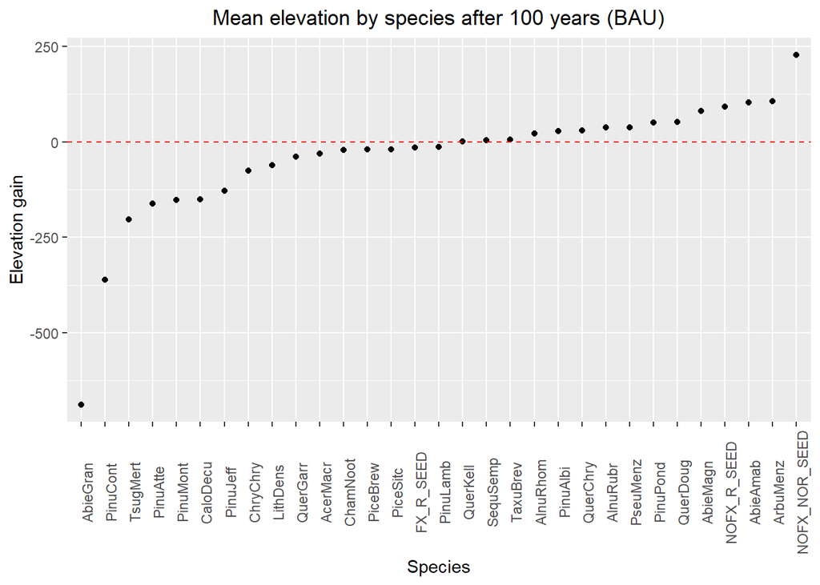

```r
ggplot(ResultSp[ResultSp$Scenario=="BAU",],
             aes(x=reorder(Name,Migration_Altitude), y=Migration_Altitude)) +
  geom_point() +
  geom_hline(yintercept=0, linetype="dashed", colour="red") +
  #geom_point(data=TotBiom, colour="red")+
  xlab("Species") +
  ylab("Elevation gain") +
  ggtitle("Mean elevation by species after 100 years (BAU)") +
  theme(plot.title = element_text(hjust = 0.5),
        axis.text.x = element_text(angle = 90))
```

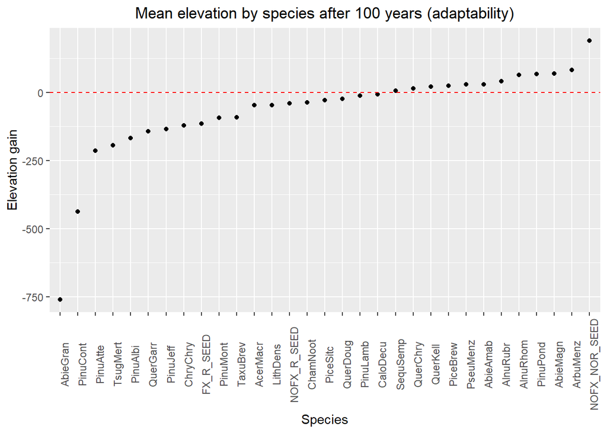

```r
ggplot(ResultSp[ResultSp$Scenario=="Adapty",],
              aes(x=reorder(Name,Migration_Altitude), y=Migration_Altitude)) +
  geom_point() +
  geom_hline(yintercept=0,  linetype="dashed", colour="red") +
  #geom_point(data=TotBiom, colour="red")+
  xlab("Species") +
  ylab("Elevation gain") +
  ggtitle("Mean elevation by species after 100 years (adaptability)") +
  theme(plot.title = element_text(hjust = 0.5),
        axis.text.x = element_text(angle = 90))
```

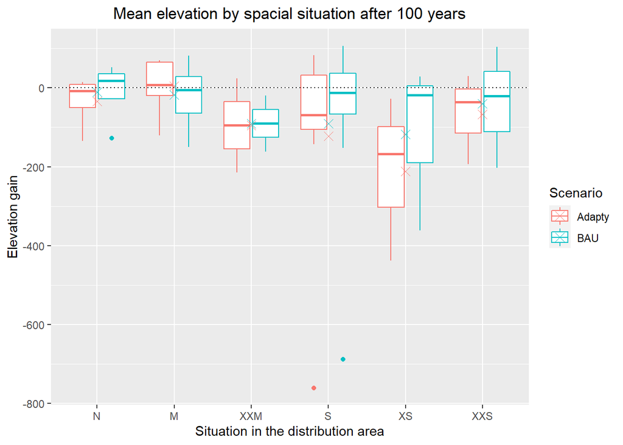

```r
ggplot(ResultTree, aes(x=Distribution, y=Migration_Altitude, col=Scenario)) +
  geom_boxplot() +
  geom_hline(yintercept=0, linetype="dotted") +
  stat_summary(fun=mean, geom="point", shape=4, size=3) +
 scale_x_discrete(name ="Situation in the distribution area",
                    limits=c("N","M","XXM","S","XS","XXS")) +
  ylab("Elevation gain") +
  ggtitle("Mean elevation by spacial situation after 100 years") +
  theme(plot.title = element_text(hjust = 0.5))
```

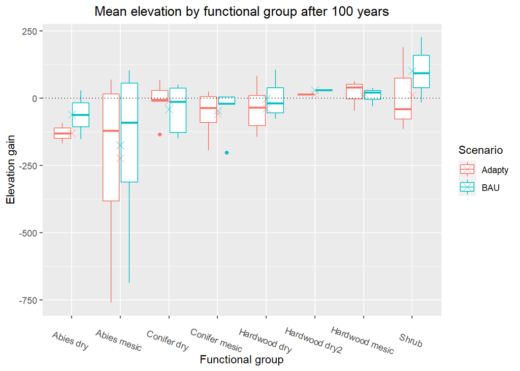

```r
ggplot(ResultSp, aes(x=Group, y=Migration_Altitude, col=Scenario)) +
  geom_boxplot() +
  geom_hline(yintercept=0, linetype="dotted") +
  stat_summary(fun=mean, geom="point", shape=4, size=3) +
  xlab("Functional group") +
  ylab("Elevation gain") +
  ggtitle("Mean elevation by functional group after 100 years") +
  theme(plot.title = element_text(hjust = 0.5),
        axis.text.x = element_text(angle = -20))
```

```r
#plot_grid(Areap, Groupp, nrow=2, labels="AUTO")
```

# V. Analyses of Soil Moisture shifts

## IV.A. Visualisation of the data

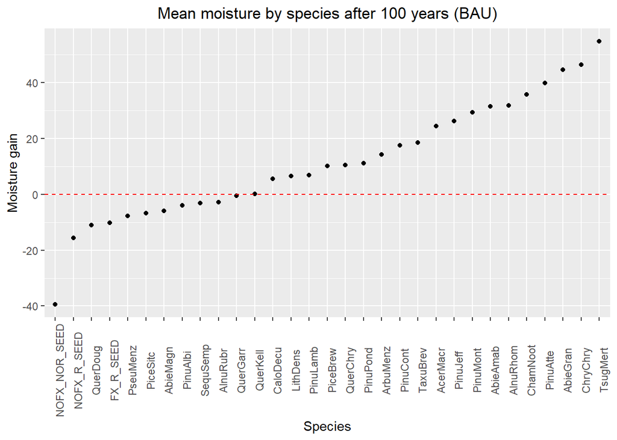

```r
ggplot(ResultSp[ResultSp$Scenario=="BAU",],
             aes(x=reorder(Name,Migration_SoilMoist), y=Migration_SoilMoist)) +
  geom_point() +
  geom_hline(yintercept=0, linetype="dashed", colour="red") +
  #geom_point(data=TotBiom, colour="red")+
  xlab("Species") +
  ylab("Moisture gain") +
  ggtitle("Mean moisture by species after 100 years (BAU)") +
  theme(plot.title = element_text(hjust = 0.5),
        axis.text.x = element_text(angle = 90))
```

[figure not shown]

```r
ggplot(ResultSp[ResultSp$Scenario=="Adapty",],
              aes(x=reorder(Name,Migration_SoilMoist), y=Migration_SoilMoist)) +
  geom_point() +
  geom_hline(yintercept=0,  linetype="dashed", colour="red") +
  #geom_point(data=TotBiom, colour="red")+
  xlab("Species") +
  ylab("Elevation gain") +
  ggtitle("Mean elevation by species after 100 years (adaptability)") +
  theme(plot.title = element_text(hjust = 0.5),
        axis.text.x = element_text(angle = 90))
```

Shrubs go in the abandoned places.

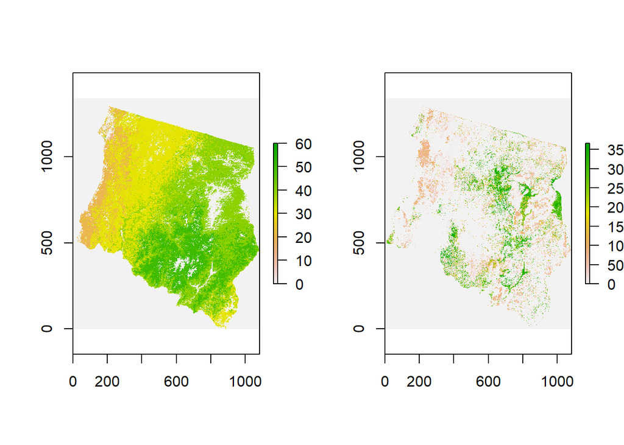

```r
FxR0 = paste0(BAU_input,"FX_R_SEED-0.tif") %>% raster()
FxR100 = paste0(BAU_input,"FX_R_SEED-100.tif") %>% raster()

NFxR0 = paste0(BAU_input,"NOFX_R_SEED-0.tif") %>% raster()
NFxR100 = paste0(BAU_input,"NoFX_R_SEED-100.tif") %>% raster()

NFxNR0 = paste0(BAU_input,"NOFX_NOR_SEED-0.tif") %>% raster()
NFxNR100 = paste0(BAU_input,"NoFX_NOR_SEED-100.tif") %>% raster()

Xer0 = FxR0 + NFxR0 + NFxNR0

Xer100 = FxR100 + NFxR100 + NFxNR100

par(mfrow=c(1,2))

plot(Xer0)
plot(Xer100)
```

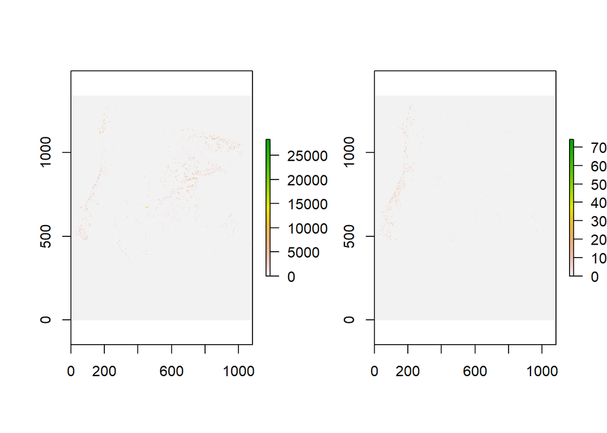

```r
ChamNoot0 = paste0(BAU_input,"ChamNoot-0.tif") %>% raster()
ChamNoot100 = paste0(BAU_input,"ChamNoot-100.tif") %>% raster()

ChamNoot0 = paste0(BAU_input,"NOFX_R_SEED-0.tif") %>% raster()
ChryChry100 = paste0(BAU_input,"NoFX_R_SEED-100.tif") %>% raster()

AbieGran0 = paste0(BAU_input,"AbieGran-0.tif") %>% raster()
AbieGran100 = paste0(BAU_input,"AbieGran-100.tif") %>% raster()

Hig0 = ChamNoot0 + ChamNoot0 + AbieGran0

Hig100 = ChamNoot100 + ChamNoot100 + AbieGran100

par(mfrow=c(1,2))

plot(Hig0)
plot(Hig100)
```

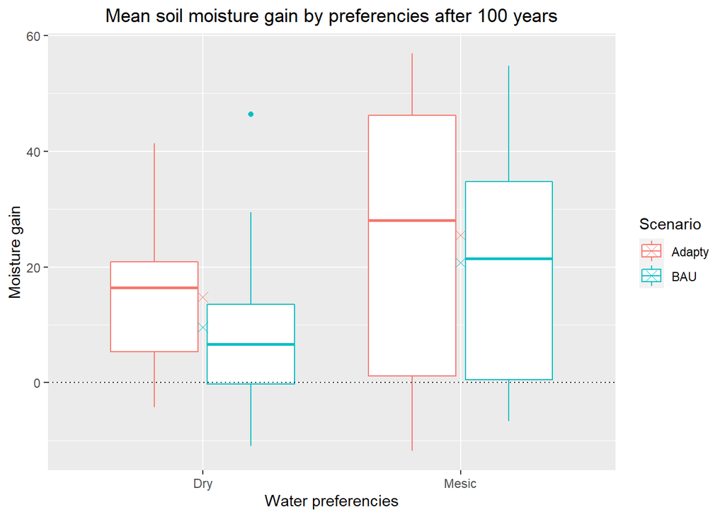

```r
ResultTree$WaterBehavior = "Shrub"

ResultTree$WaterBehavior[which(ResultTree$Group == "Abies dry" |
                            ResultTree$Group == "Hardwood dry" |
                            ResultTree$Group == "Conifer dry" |
                            ResultTree$Group == "Hardwood dry2")] = "Dry"

ResultTree$WaterBehavior[which(ResultTree$Group == "Hardwood mesic" |
                            ResultTree$Group == "Abies mesic" |
                            ResultTree$Group == "Conifer mesic")]= "Mesic"

ggplot(ResultTree, aes(x=WaterBehavior, y=Migration_SoilMoist, col=Scenario)) +
  geom_boxplot() +
  geom_hline(yintercept=0, linetype="dotted") +
  stat_summary(fun=mean, geom="point", shape=4, size=3) +
 scale_x_discrete(name ="Water preferencies") +
  ylab("Moisture gain") +
  ggtitle("Mean soil moisture gain by preferencies after 100 years") +
  theme(plot.title = element_text(hjust = 0.5))
```

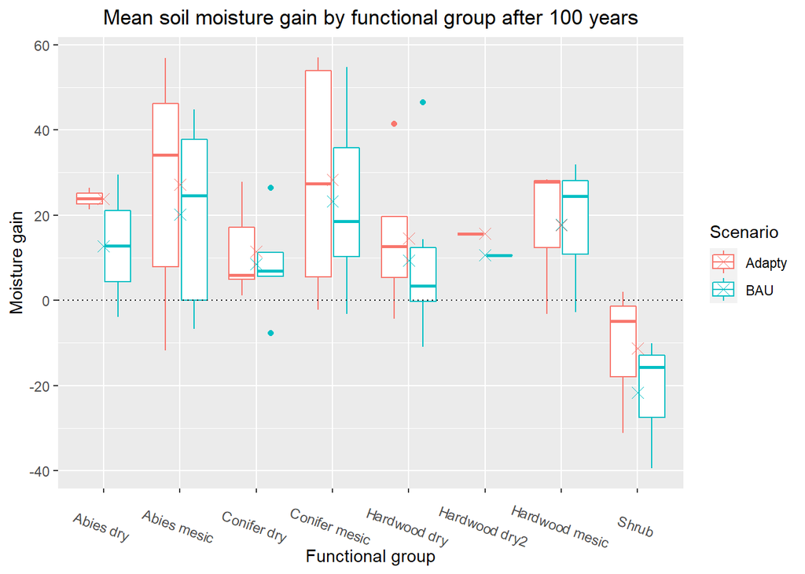

```r
ggplot(ResultSp, aes(x=Group, y=Migration_SoilMoist, col=Scenario)) +
  geom_boxplot() +
  geom_hline(yintercept=0, linetype="dotted") +
  stat_summary(fun=mean, geom="point", shape=4, size=3) +
  xlab("Functional group") +
  ylab("Moisture gain") +
  ggtitle("Mean soil moisture gain by functional group after 100 years") +
  theme(plot.title = element_text(hjust = 0.5),
        axis.text.x = element_text(angle = -20))
```

```r
#plot_grid(Areap, Groupp, nrow=2, labels="AUTO")
```

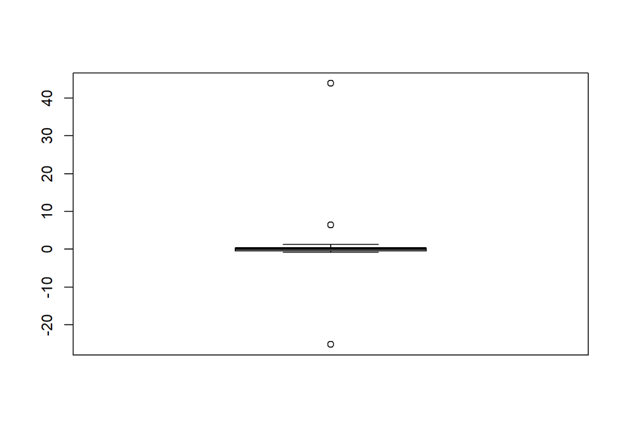

```r
boxplot(Dif$SoilMoist_Dif)
```

```r
shapiro.test(Dif$SoilMoist_Dif)
```

```
##
##  Shapiro-Wilk normality test
##
## data:  Dif$SoilMoist_Dif
## W = 0.40707, p-value = 4.27e-10
```